# 1970s avian bioregion cluster species and environmental driver profiles

WM

2026-05-06

## Aim

This notebook asks which species characterize the 1970s modelled avian bioregion clusters, and which environmental variables are most important for those species.

The clusters are the Atlas 1 reference clusters from the avian bioregion PCA. Species are not assigned to clusters with a hard cutoff. Instead, each species gets a cluster-specific weight equal to its share of total modelled expected occurrence in that 1970s cluster. Environmental driver summaries then use those species weights to summarize Atlas 1 scaled variance partitioning (VP) and supported Atlas 1 Beta effects.

## Methods

For each 1970s cluster, predicted species probabilities were summed across all grid cells in the cluster. A species weight is the species’ expected occurrence sum divided by the total expected occurrence summed over all species in that cluster. The weights therefore describe the modelled composition of each cluster.

Scaled VP values are Atlas 1 variable contributions multiplied by species Tjur R2, following the Fig. 2 workflow. Beta effects are used only where posterior support is high enough for `read_parameter_effects()` to retain the estimate. Unsupported effects are treated as unknown direction, not as zero effects.

The waffle chart combines these two pieces of information. For every supported `species x environmental variable` Beta association, the contribution is:

`species expected occurrence share in the 1970s cluster x species scaled VP for that environmental variable`

The resulting values are summed by `Cluster x Beta sign x environmental variable`. Each waffle is then normalized within a `Cluster x Beta sign` combination, so the tiles show the relative composition of weighted supported environmental dependency among positive or negative species associations.

The PCA uses the same species-level dependency profiles as the waffle chart, but retains the raw multivariate structure before aggregation. For each `Cluster x species`, each environmental variable is split into positive and negative supported-dependency features. Cluster 3 species profiles are used to fit the reference PCA, and Cluster 1 and Cluster 2 species profiles are then projected into that same Cluster 3 environmental-dependency space.

## Weighted Species-Level Driver Waffles

This plot keeps the analysis close to individual species, but summarizes the species-level information as proportional waffles rather than a large species table. All species in each 1970s cluster are included. For each supported `species x environmental variable` Beta association, the contribution is the species’ expected occurrence share in that cluster multiplied by the species’ scaled VP for that environmental variable. The waffle therefore asks: among the modelled species that make up a cluster, which environmental dependencies are most represented among positive and negative supported associations?

Each waffle is normalized within a `Cluster x Beta sign` combination. A tile is approximately 1% of the weighted supported dependency in that waffle. The tile colours show the environmental variables.

## Cluster 3 Reference PCA

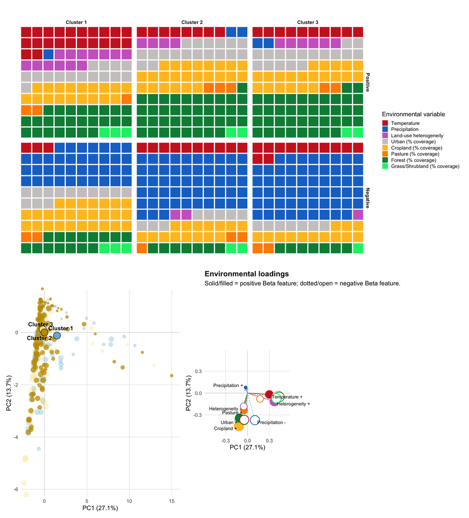